# MA677_Final

Sky Liu

5/7/2019

# Statistics and the Law

```r
# read data
acorn<-read.csv("acorn.csv")
#calculate effect size
ef<-cohen.d(acorn$MIN,acorn$WHITE)
ef$estimate
```

```
## [1] 1.98
```

```r
# n = 20
pwr.t.test(
n = dim(acorn)[1], ef$estimate,
sig.level = 0.05, power = NULL, type = c("two.sample")
)
```

```
##
##      Two-sample t test power calculation
##
##               n = 20
##               d = 1.98
##       sig.level = 0.05
##           power = 1
##     alternative = two.sided
##
## NOTE: n is number in *each* group
```

```r
# when power = 0.95, n = ?
pwr.t.test(
  n = NULL, ef$estimate,
  sig.level = 0.05, power = 0.95, type = c("two.sample")
  )
```

```
##
##      Two-sample t test power calculation
##
##               n = 7.75
##               d = 1.98
##       sig.level = 0.05
##           power = 0.95
##     alternative = two.sided
##
## NOTE: n is number in *each* group
```

```r
# t-test
t.test(acorn$MIN, acorn$WHITE)
```

```
##
##  Welch Two Sample t-test
##
## data:  acorn$MIN and acorn$WHITE
## t = 6, df = 30, p-value = 0.0000006
## alternative hypothesis: true difference in means is not equal to 0
## 95 percent confidence interval:
##  14.3 28.2
## sample estimates:
## mean of x mean of y
##      36.9      15.6
```

We used two sample t-test to explore the discrimination to warrant corrective action. The power of the t-test is 1 and the p value is small enough to reject the null hypothesis of no discrimination.

To verify if the data has enough evidence, we found that when n >= 8, the power of t-test would be greater than 0.95. Therefore, given we have n = 20 in this data, it is a sufficient evidence.

# Comparing Suppliers

```r
Dead_Bird=c(12,8,21);Display_Art=c(23,12,30);Flying_Art=c(89,62,119)
orithopter <- as.data.frame(cbind(Dead_Bird,Display_Art,Flying_Art))
rownames(orithopter) <- c("Area 51","BDV","Giffen")
chisq.test(orithopter)
```

```
##
##  Pearson's Chi-squared test
##
## data:  orithopter
## X-squared = 1, df = 4, p-value = 0.9
```

# How deadly are sharks?

```r
shark<-read.csv("sharkattack.csv")



#Fatal
USshark_fatal <- shark %>%
  filter(Country == "United States" ) %>%
  filter(Fatal == "Y" | Fatal == "N")%>%
  mutate(Fatal_code = ifelse(Fatal == "Y", 1, 0))

AUshark_fatal <- shark %>%
  filter(Country == "Australia" ) %>%
  filter(Fatal == "Y" | Fatal == "N")%>%
  mutate(Fatal_code = ifelse(Fatal == "Y", 1, 0))


#calculate effect size
ef<-cohen.d(AUshark_fatal$Fatal_code,USshark_fatal$Fatal_code)
ef$estimate
```

```
## [1] 0.432
```

```r
# n = 20
pwr.t.test(
  n = dim(USshark_fatal)[1], ef$estimate,
  sig.level = 0.05, power = NULL, type = c("two.sample"),
  alternative = "greater"
  )
```

```
##
##      Two-sample t test power calculation
##
##               n = 2012
##               d = 0.432
##       sig.level = 0.05
##           power = 1
##     alternative = greater
##
## NOTE: n is number in *each* group
```

```r
# proportion z-test
prop.test( x = c(
  sum(AUshark_fatal$Fatal_code == 1),
  sum(USshark_fatal$Fatal_code == 1) ),
n = c(dim(AUshark_fatal)[1], dim(USshark_fatal)[1]),
  alternative = "greater"
)
```

```
##
##  2-sample test for equality of proportions with continuity
##  correction
##
## data:  c(sum(AUshark_fatal$Fatal_code == 1), sum(USshark_fatal$Fatal_code ==  out of c(dim(AUshark_fatal)[1], dim(USshark_fatal)[1])    1)) out of c(dim(AUshark_fatal)[1], dim(USshark_fatal)[1])
## X-squared = 100, df = 1, p-value <0.0000000000000002
## alternative hypothesis: greater
## 95 percent confidence interval:
##  0.133 1.000
## sample estimates:
## prop 1 prop 2
##  0.266  0.108
```

By calculating the effect size and power analysis, we obtained the power being 1. Then, by performing a two sample test for null hypothesis that AU sharks are less or equally fatal than US shark. We obtained a p-value small enough to reject the null hypothesis.

# Power Analysis

As discussed in Cohen’s $\textit{Statistical Power Analysis for the Behavioral Sciences}$, the equal difference between two P value can be detected with different power, thus P cannot provide a scale of equal units of detectability. Therefore, the difference between P’s is not an appropriate index of effect size.

Arcsine transformation of P value solves this problem. By taking $\phi = 2 arcsine \sqrt{P}$, equal difference between $\phi$s can be detected. Unlike, $P_1 - P_2$, the value of $h = \phi_1 - \phi_2$ does not depend of value of $\phi$s and where it falls in its possibility range. Therefore, we can use to represent effect size index for a difference in proportion.

# Estimators

## Exponential

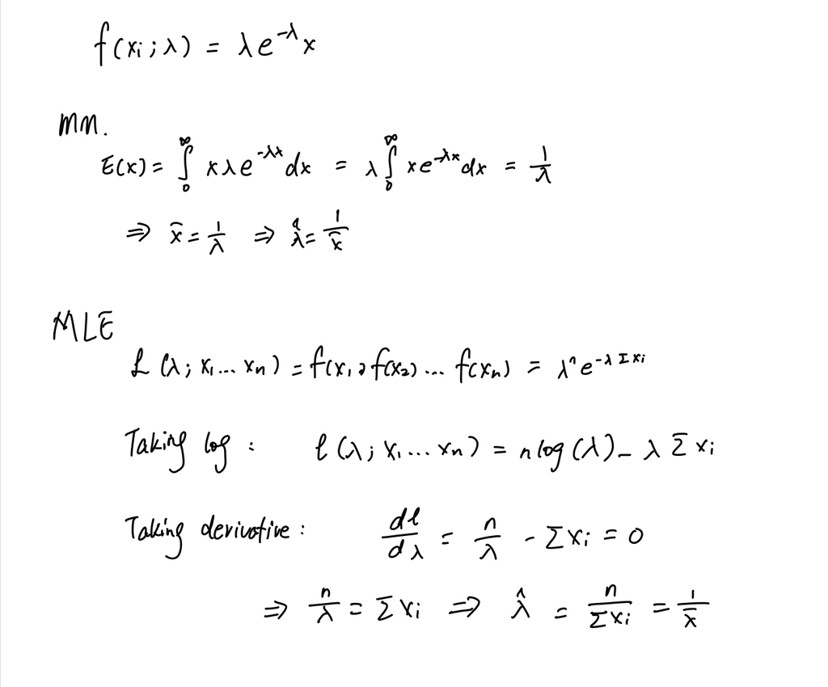

## A new distribution

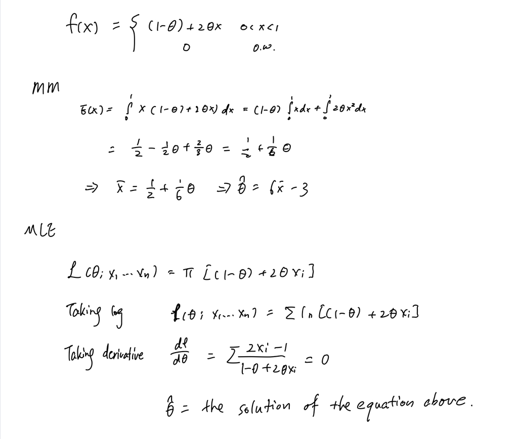

## Rain in Southern Illinois